# Lab Session: PCA and PCR

Class 9

## Lab: PCA and PCR using Hitters Data

In this lab, we will explore Principal Component Analysis (PCA) as an unsupervised technique for dimensionality reduction and visualization, and then apply Principal Component Regression (PCR) as a supervised learning method. We’ll use the `Hitters` dataset from the `ISLR2` package, which contains statistics for baseball players along with their salaries.

```r
rm(list = ls())
pacman::p_unload(pacman::p_loaded())
pacman::p_load(tidyverse, cluster, factoextra, here, knitr, ISLR2, ggsci)
```

### Data, EDA, & Preprocessing

First, we load the `Hitters` dataset. It contains player statistics from the 1986 season and salary data for the 1987 season.

```r
data("Hitters", package = "ISLR2")
print(str(Hitters))
```

```
## 'data.frame':    322 obs. of  20 variables:
##  $ AtBat    : int  293 315 479 496 321 594 185 298 323 401 ...
##  $ Hits     : int  66 81 130 141 87 169 37 73 81 92 ...
##  $ HmRun    : int  1 7 18 20 10 4 1 0 6 17 ...
##  $ Runs     : int  30 24 66 65 39 74 23 24 26 49 ...
##  $ RBI      : int  29 38 72 78 42 51 8 24 32 66 ...
##  $ Walks    : int  14 39 76 37 30 35 21 7 8 65 ...
##  $ Years    : int  1 14 3 11 2 11 2 3 2 13 ...
##  $ CAtBat   : int  293 3449 1624 5628 396 4408 214 509 341 5206 ...
##  $ CHits    : int  66 835 457 1575 101 1133 42 108 86 1332 ...
##  $ CHmRun   : int  1 69 63 225 12 19 1 0 6 253 ...
##  $ CRuns    : int  30 321 224 828 48 501 30 41 32 784 ...
##  $ CRBI     : int  29 414 266 838 46 336 9 37 34 890 ...
##  $ CWalks   : int  14 375 263 354 33 194 24 12 8 866 ...
##  $ League   : Factor w/ 2 levels "A","N": 1 2 1 2 2 1 2 1 2 1 ...
##  $ Division : Factor w/ 2 levels "E","W": 1 2 2 1 1 2 1 2 2 1 ...
##  $ PutOuts  : int  446 632 880 200 805 282 76 121 143 0 ...
##  $ Assists  : int  33 43 82 11 40 421 127 283 290 0 ...
##  $ Errors   : int  20 10 14 3 4 25 7 9 19 0 ...
##  $ Salary   : num  NA 475 480 500 91.5 750 70 100 75 1100 ...
##  $ NewLeague: Factor w/ 2 levels "A","N": 1 2 1 2 2 1 1 1 2 1 ...
## NULL
```

```r
print(summary(Hitters))
```

```
##      AtBat            Hits         HmRun            Runs
##  Min.   : 16.0   Min.   :  1   Min.   : 0.00   Min.   :  0.00
##  1st Qu.:255.2   1st Qu.: 64   1st Qu.: 4.00   1st Qu.: 30.25
##  Median :379.5   Median : 96   Median : 8.00   Median : 48.00
##  Mean   :380.9   Mean   :101   Mean   :10.77   Mean   : 50.91
##  3rd Qu.:512.0   3rd Qu.:137   3rd Qu.:16.00   3rd Qu.: 69.00
##  Max.   :687.0   Max.   :238   Max.   :40.00   Max.   :130.00
##
##       RBI             Walks            Years            CAtBat
##  Min.   :  0.00   Min.   :  0.00   Min.   : 1.000   Min.   :   19.0
##  1st Qu.: 28.00   1st Qu.: 22.00   1st Qu.: 4.000   1st Qu.:  816.8
##  Median : 44.00   Median : 35.00   Median : 6.000   Median : 1928.0
##  Mean   : 48.03   Mean   : 38.74   Mean   : 7.444   Mean   : 2648.7
##  3rd Qu.: 64.75   3rd Qu.: 53.00   3rd Qu.:11.000   3rd Qu.: 3924.2
##  Max.   :121.00   Max.   :105.00   Max.   :24.000   Max.   :14053.0
##
##      CHits            CHmRun           CRuns             CRBI
##  Min.   :   4.0   Min.   :  0.00   Min.   :   1.0   Min.   :   0.00
##  1st Qu.: 209.0   1st Qu.: 14.00   1st Qu.: 100.2   1st Qu.:  88.75
##  Median : 508.0   Median : 37.50   Median : 247.0   Median : 220.50
##  Mean   : 717.6   Mean   : 69.49   Mean   : 358.8   Mean   : 330.12
##  3rd Qu.:1059.2   3rd Qu.: 90.00   3rd Qu.: 526.2   3rd Qu.: 426.25
##  Max.   :4256.0   Max.   :548.00   Max.   :2165.0   Max.   :1659.00
##
##      CWalks        League  Division    PutOuts          Assists
##  Min.   :   0.00   A:175   E:157    Min.   :   0.0   Min.   :  0.0
##  1st Qu.:  67.25   N:147   W:165    1st Qu.: 109.2   1st Qu.:  7.0
##  Median : 170.50                    Median : 212.0   Median : 39.5
##  Mean   : 260.24                    Mean   : 288.9   Mean   :106.9
##  3rd Qu.: 339.25                    3rd Qu.: 325.0   3rd Qu.:166.0
##  Max.   :1566.00                    Max.   :1378.0   Max.   :492.0
##
##      Errors          Salary       NewLeague
##  Min.   : 0.00   Min.   :  67.5   A:176
##  1st Qu.: 3.00   1st Qu.: 190.0   N:146
##  Median : 6.00   Median : 425.0
##  Mean   : 8.04   Mean   : 535.9
##  3rd Qu.:11.00   3rd Qu.: 750.0
##  Max.   :32.00   Max.   :2460.0
##                  NA's   :59
```

#### Handling Missing Data:

The `Salary` variable has missing values. We need to remove these observations before proceeding with PCA and PCR, as these methods typically require complete data.

```
## Number of missing Salary values: 59
```

```
## Dimensions after removing missing Salary: 263 20
```

```
## Number of missing values remaining: 0
```

#### Scaling Consideration

PCA is sensitive to the scale of the variables. Variables with larger variances will disproportionately influence the principal components. Since the predictors in `Hitters` are on different scales (e.g., number of hits vs. number of years), it’s crucial to standardize them before performing PCA. We will use the built-in scaling options in the `prcomp` and `pcr` functions rather than scaling manually here.

#### Train/Test Split

For PCR, we need to evaluate model performance on unseen data. We’ll split the data into a training set (2/3) and a test set (1/3)

```
## Training set size: 175
```

```
## Test set size: 88
```

### Principal Component Analysis (PCA)

#### Running PCA

PCA is an unsupervised method used to find linear combinations of the original predictors (principal components) that capture the maximum variance in the data. We perform PCA on the predictor variables of the training data. Note that `Salary` (the response) and non-numeric predictors are excluded from the PCA itself.

```r
numeric_predictors_train <- train_data %>%
  select_if(is.numeric) %>%
  select(-Salary) # exclude the response variable

# PCA using prcomp(), scaling the variables
pca_result <- prcomp(numeric_predictors_train, scale. = TRUE)

# summary of PCA results
print(summary(pca_result)) # standard deviation, PVE, cumulative PVE
```

```
## Importance of components:
##                          PC1    PC2    PC3     PC4     PC5     PC6     PC7
## Standard deviation     2.731 1.9995 1.3186 0.96465 0.81198 0.65942 0.48230
## Proportion of Variance 0.466 0.2499 0.1087 0.05816 0.04121 0.02718 0.01454
## Cumulative Proportion  0.466 0.7159 0.8246 0.88273 0.92394 0.95112 0.96565
##                            PC8     PC9    PC10    PC11    PC12    PC13    PC14
## Standard deviation     0.43351 0.34840 0.29156 0.24782 0.22127 0.16055 0.11182
## Proportion of Variance 0.01175 0.00759 0.00531 0.00384 0.00306 0.00161 0.00078
## Cumulative Proportion  0.97740 0.98499 0.99030 0.99414 0.99720 0.99881 0.99959
##                           PC15    PC16
## Standard deviation     0.07345 0.03404
## Proportion of Variance 0.00034 0.00007
## Cumulative Proportion  0.99993 1.00000
```

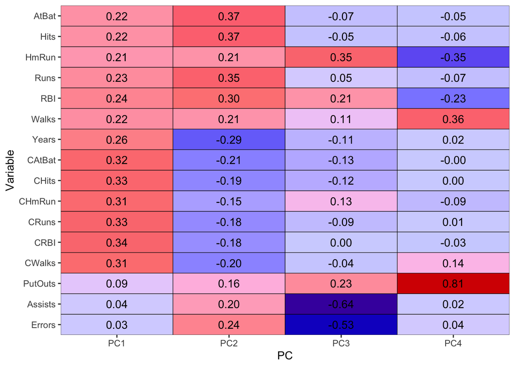

```r
#  principal component loadings (rotation matrix)
pc_4 <- data.frame(round(pca_result$rotation[, 1:4], 3))
pc_4$names <- rownames(pc_4)
pc_4$names <- factor(pc_4$names, levels = rev(pc_4$names))
pc_4 |>
  pivot_longer(cols = -names) |>
  ggplot(aes(x = name, y = names)) +
  geom_tile(aes(fill = value), color = "black") +
  geom_text(aes(label = sprintf("%0.2f", value))) +
  scale_x_discrete(expand = c(0, 0)) +
  scale_y_discrete(expand = c(0, 0)) +
  labs(x = "PC", y = "Variable") +
  scale_fill_gsea() +
  theme(legend.position = "none")
```

Interpretation of PCA Results:

- The `summary` output shows the standard deviation, proportion of variance explained (PVE), and cumulative proportion of variance for each principal component.
- The rotation matrix contains the principal component loading vectors. Each column represents a component, and the values are the weights applied to the original scaled variables to create that component.
- PC1: The loadings for the first principal component (PC1) are predominantly positive and largest for career statistics (`CAtBat`, `CHits`, `CHmRun`, `CRuns`, `CRBI`, `CWalks`) and `Years.` It also gives substantial positive weight to current season offensive stats (`AtBat`, `Hits`, `Runs`, `RBI`, `Walks`). This suggests PC1 is a measure of overall career offensive performance and experience. Players scoring high on PC1 are established players with strong cumulative stats.
- PC2: PC2: The second principal component (PC2) shows a contrast. It has strong positive loadings for current season offensive performance (`AtBat`, `Hits`, `Runs`, `RBI`) but negative loadings for `Years` and career statistics (`CAtBat` through `CWalks`). This component seems to capture current season offensive performance relative to career length/performance. A player scoring high on PC2 might be having a strong current season but is possibly earlier in their career or less accomplished overall compared to someone with a similar PC1 score.

#### Variance explained

We can visualize the PVE to help decide how many components capture most of the data’s variability. The scree plot is a common tool for this.

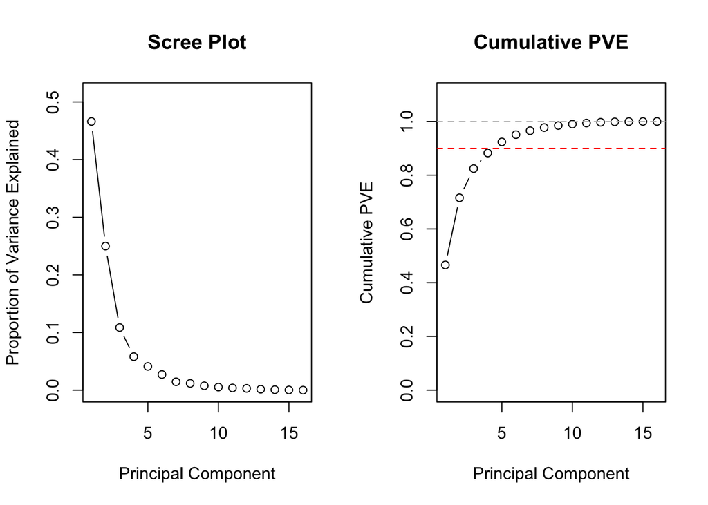

```r
#  PVE from standard deviations
pve <- pca_result$sdev^2 / sum(pca_result$sdev^2)
cumulative_pve <- cumsum(pve) # Use cumsum() for cumulative PVE

# PVE (Scree Plot) and Cumulative PVE
par(mfrow = c(1, 2))
plot(pve, type = "b", main = "Scree Plot",
     xlab = "Principal Component", ylab = "Proportion of Variance Explained",
     ylim = c(0, max(pve)*1.1)) # Scree plot
plot(cumulative_pve, type = "b", main = "Cumulative PVE",
     xlab = "Principal Component", ylab = "Cumulative PVE",
     ylim = c(0, 1.1)) # Cumulative PVE plot
abline(h = 0.9, col = "red", lty = 2) # Example threshold at 90%
abline(h = 1.0, col = "grey", lty = 2)
```

```r
par(mfrow = c(1, 1))
```

### Principal Component Regression (PCR)

```r
library(pls) # Load pls package
set.seed(42)
#  scale=TRUE to standardize predictors
#  validation="CV" for cross-validation
pcr_fit <- pcr(Salary ~ ., data = train_data, scale = TRUE, validation = "CV")
#  summary
summary(pcr_fit) # CV scores and variance explained
```

```
## Data:    X dimension: 175 19
##  Y dimension: 175 1
## Fit method: svdpc
## Number of components considered: 19
##
## VALIDATION: RMSEP
## Cross-validated using 10 random segments.
##        (Intercept)  1 comps  2 comps  3 comps  4 comps  5 comps  6 comps
## CV           438.1    335.5    340.2    343.8    337.8    325.7    325.0
## adjCV        438.1    335.1    339.6    343.3    336.8    324.4    323.9
##        7 comps  8 comps  9 comps  10 comps  11 comps  12 comps  13 comps
## CV       331.3    334.1    338.8     337.3     338.7     339.1     337.1
## adjCV    329.9    332.5    336.9     335.2     336.7     337.0     335.0
##        14 comps  15 comps  16 comps  17 comps  18 comps  19 comps
## CV        339.2     338.9     329.5     330.6     325.0     324.4
## adjCV     337.0     336.4     327.2     328.2     322.6     321.7
##
## TRAINING: % variance explained
##         1 comps  2 comps  3 comps  4 comps  5 comps  6 comps  7 comps  8 comps
## X         39.42    60.58    71.03    79.95    85.18    89.65    93.10    95.37
## Salary    43.36    43.36    43.67    46.31    50.33    51.33    51.34    51.51
##         9 comps  10 comps  11 comps  12 comps  13 comps  14 comps  15 comps
## X         96.59     97.59     98.24     98.80     99.22     99.53     99.77
## Salary    51.97     52.98     53.02     53.15     53.83     54.04     54.86
##         16 comps  17 comps  18 comps  19 comps
## X          99.90     99.97     99.99    100.00
## Salary     56.73     57.14     58.77     60.09
```

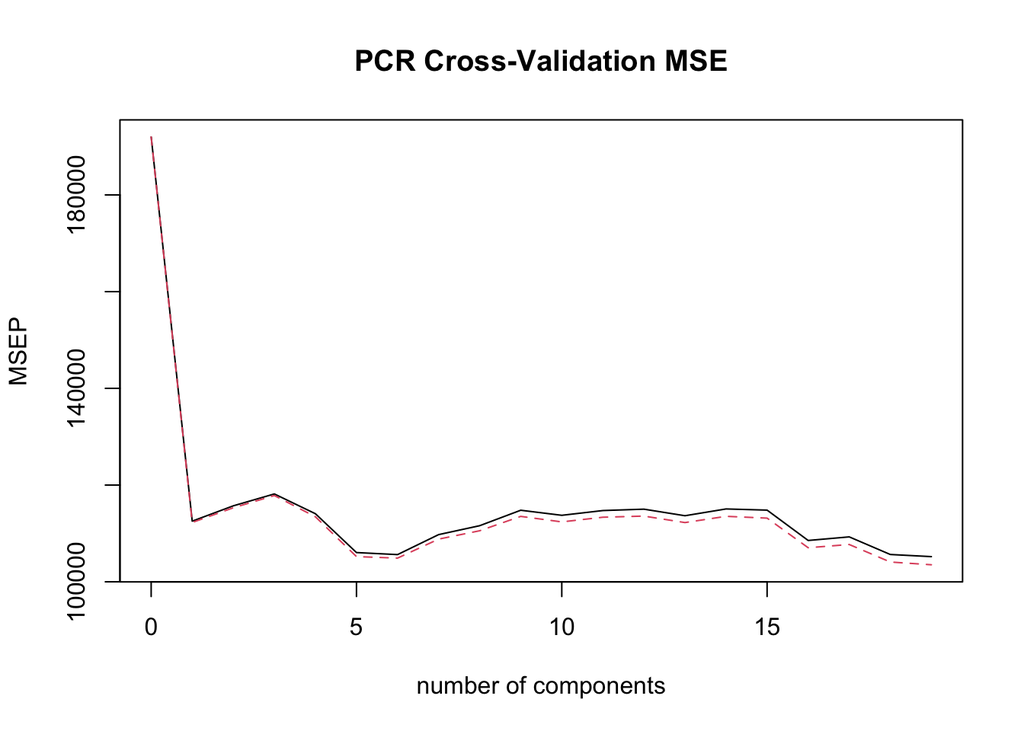

[output not shown]

```
## Test MSE for PCR with M = 5 components: 148926.6
```

```
## Test MSE for PCR with all components: 136560.5
```